# beer recipes

Junjie Cai

1 June 2018

## Read and pre-process the file

```r
library(MASS)
library(tree)
library(knitr)
library(ggplot2)

rawRecipe = read.csv("recipeData.csv", na.strings = "N/A")
summary(rawRecipe)
```

```
##      BeerID                  Name                       URL
##  Min.   :    1   Awesome Recipe: 1311   American IPA      :    7
##  1st Qu.:18466   IPA           :  197   Saison            :    6
##  Median :36931   Saison        :  181   Weissbier         :    6
##  Mean   :36931   Kölsch        :  173   American Amber Ale:    5
##  3rd Qu.:55396   Black IPA     :  129   American Pale Ale :    4
##  Max.   :73861   (Other)       :71869   Imperial IPA      :    4
##                  NA's          :    1   (Other)           :73829
##                   Style          StyleID          Size.L.
##  American IPA        :11933   Min.   :  1.00   Min.   :   1.00
##  American Pale Ale   : 7577   1st Qu.: 10.00   1st Qu.:  18.93
##  Saison              : 2611   Median : 35.00   Median :  20.82
##  American Light Lager: 2274   Mean   : 60.13   Mean   :  43.90
##  American Amber Ale  : 2033   3rd Qu.:111.00   3rd Qu.:  23.66
##  (Other)             :46837   Max.   :540.00   Max.   :9200.00
##  NA's                :  596
##        OG               FG              ABV               IBU
##  Min.   : 1.000   Min.   :-0.003   Min.   :  0.000   Min.   :   0.00
##  1st Qu.: 1.051   1st Qu.: 1.011   1st Qu.:  5.080   1st Qu.:  23.33
##  Median : 1.058   Median : 1.013   Median :  5.790   Median :  35.76
##  Mean   : 1.405   Mean   : 1.081   Mean   :  6.175   Mean   :  44.24
##  3rd Qu.: 1.069   3rd Qu.: 1.017   3rd Qu.:  6.830   3rd Qu.:  56.34
##  Max.   :34.035   Max.   :23.425   Max.   :156.540   Max.   :3409.30
##
##      Color           BoilSize          BoilTime       BoilGravity
##  Min.   :  0.00   Min.   :   1.00   Min.   :  0.00   Min.   : 0.000
##  1st Qu.:  5.17   1st Qu.:  20.82   1st Qu.: 60.00   1st Qu.: 1.040
##  Median :  8.44   Median :  27.44   Median : 60.00   Median : 1.047
##  Mean   : 13.43   Mean   :  49.75   Mean   : 65.01   Mean   : 1.424
##  3rd Qu.: 16.82   3rd Qu.:  30.00   3rd Qu.: 60.00   3rd Qu.: 1.060
##  Max.   :600.50   Max.   :9700.00   Max.   :240.00   Max.   :84.000
##                                     NA's   :3        NA's   :2987
##    Efficiency     MashThickness              SugarScale
##  Min.   :  0.00   1.5    :15492   All Grain       :   61
##  1st Qu.: 65.00   3      : 8285   BIAB            :   10
##  Median : 70.00   1.25   : 4921   extract         :    3
##  Mean   : 66.31   2.5    : 1863   Partial Mash    :    3
##  3rd Qu.: 75.00   1.3    : 1110   Plato           : 1896
##  Max.   :100.00   (Other):12350   Specific Gravity:71888
##  NA's   :24       NA's   :29840
##         BrewMethod      PitchRate      PrimaryTemp       PrimingMethod
##  All Grain   :49631   Min.   : 0.00   20     :14172   Corn Sugar:  715
##  BIAB        :12006   1st Qu.: 0.35   21.11  : 4621   Dextrose  :  501
##  extract     : 8623   Median : 0.75   18.33  : 4181   corn sugar:  360
##  Partial Mash: 3524   Mean   : 0.78   18     : 4120   Keg       :  330
##  0.35        :   12   3rd Qu.: 1.00   19     : 2667   Sugar     :  309
##  (Other)     :   24   Max.   :26.67   (Other):21390   (Other)   : 4550
##  NA's        :   41   NA's   :39231   NA's   :22710   NA's      :67096
##  PrimingAmount
##  5 oz   :  205
##  3/4 cup:  110
##  4 oz   :  106
##  1 cup  :  102
##  5oz    :   92
##  (Other): 4232
##  NA's   :69014
```

```r
recipes = rawRecipe[,c(4,7:11)]
recipes = na.omit(recipes)

# we delete some outliers in data set
outlier = which(recipes$OG>1.5 | recipes$FG>1.5 | recipes$ABV>15 |recipes$IBU>100 | recipes$Color>40)
recipes = recipes[-outlier,]
summary(recipes)
```

```
##                   Style             OG              FG
##  American IPA        : 9998   Min.   :1.000   Min.   :0.991
##  American Pale Ale   : 7234   1st Qu.:1.050   1st Qu.:1.010
##  Saison              : 2553   Median :1.056   Median :1.013
##  American Light Lager: 2010   Mean   :1.059   Mean   :1.013
##  American Amber Ale  : 1950   3rd Qu.:1.065   3rd Qu.:1.016
##  Blonde Ale          : 1698   Max.   :1.260   Max.   :1.208
##  (Other)             :38506
##       ABV              IBU             Color
##  Min.   : 0.000   Min.   :  0.00   Min.   : 0.00
##  1st Qu.: 5.030   1st Qu.: 22.59   1st Qu.: 4.99
##  Median : 5.670   Median : 33.92   Median : 8.01
##  Mean   : 5.924   Mean   : 37.58   Mean   :11.79
##  3rd Qu.: 6.590   3rd Qu.: 50.20   3rd Qu.:15.13
##  Max.   :15.000   Max.   :100.00   Max.   :40.00
##
```

finally, we get the data which will be actually analyzed in next step.

## Question 1 – Predict the Style using other variables

#### KNN function

Firstly, we standardize variables and then divide standardized dataset into training and test set at 9:1 ratio.

```r
standardized.recipes= scale(recipes[,-1])
recipes.std <- data.frame(Style = recipes$Style, standardized.recipes)

set.seed(1234)
train.row = sample(1:nrow(recipes), 0.9*nrow(recipes))
recipes.std.train = recipes.std[train.row,]
recipes.std.test = recipes.std[-train.row,]
```

then we apply KNN function (K from 1 to 100) on our training set.

```r
library(class)
accuracy <- rep(0,100)
for (i in 1:100) {
    predicted.style <- knn(recipes.std.train[,-1],recipes.std.test[,-1],recipes.std.train$Style,k=i)
    accuracy[i] <- sum(recipes.std.test$Style==predicted.style)/length(predicted.style)
}
library(ggplot2)
qplot(1:100,accuracy,geom="line", xlab="K", ylab="Accuracy", main = "Accuracy of KNN")
```

[output not shown]

Consequently, KNN method is not working very well in my dataset, for several reasons. Firstly, since there are more than 60 thousands observations and over 200 labels in my dataset, a low accuracy of KNN method is foreseeing. The KNN method does not work well for the dataset with a lot of labels. In addition, since the K value refers to K neighbors we should consider nearest to the data point, therefore, a large K value will result in a huge amount of computing process, which consumes more memory and computing resources. In fact, it is pretty slow for my computer to process KNN function in this experiment when I apply K up to 100. Or in other hand, we could say that variables in the dataset is not good enough to precisely predict the beer styles when using KNN function.

## Question 2 – Relationship between `color` and other variables.

Now I will create a new qualitative variable called “Dark” with the two values (“yes” or “no”) to indicate that whether the color of beers is “dark” or not, according to the numeric value of “Color”. In this project, a dark beer has the value of “Color” larger than 25.

```r
recipes.X = recipes[,-1] # extract beeer features except the Style
recipes.X$Dark = rep("no",nrow(recipes.X))
recipes.X$Dark[recipes.X$Color>25]="yes"
recipes.X$Dark = factor(recipes.X$Dark)
recipes.X$Color = NULL # remove Color

# divide training and test set
recipes.X.train = recipes.X[train.row,]
recipes.X.test = recipes.X[-train.row,]
```

#### Random guessing error rate

```r
# random guessing error rate
summary(recipes.X$Dark)
```

```
##    no   yes
## 56186  7763
```

```r
7763/nrow(recipes.X)
```

```
## [1] 0.1213936
```

#### Logistic regression

Then we build the model and then predict the probability of the dark beer.

```r
m.log = glm(Dark~., data = recipes.X.train, family = binomial)
summary(m.log)
```

```
##
## Call:
## glm(formula = Dark ~ ., family = binomial, data = recipes.X.train)
##
## Deviance Residuals:
##     Min       1Q   Median       3Q      Max
## -5.7848  -0.5273  -0.4382  -0.3603   2.9325
##
## Coefficients:
##               Estimate Std. Error z value Pr(>|z|)
## (Intercept) -1.425e+02  3.415e+00 -41.722  < 2e-16 ***
## OG          -7.428e+00  1.805e+01  -0.411   0.6808
## FG           1.461e+02  1.830e+01   7.987 1.39e-15 ***
## ABV          1.565e-02  1.372e-01   0.114   0.9091
## IBU          1.373e-03  5.988e-04   2.294   0.0218 *
## ---
## Signif. codes:  0 '***' 0.001 '**' 0.01 '*' 0.05 '.' 0.1 ' ' 1
##
## (Dispersion parameter for binomial family taken to be 1)
##
##     Null deviance: 42623  on 57553  degrees of freedom
## Residual deviance: 40038  on 57549  degrees of freedom
## AIC: 40048
##
## Number of Fisher Scoring iterations: 5
```

```r
gl.probs = predict(m.log,type = "response", newdata = recipes.X.test)
gl.pred=rep ("no" ,nrow(recipes.X.test))
gl.pred[gl.probs > 0.5]=" yes"
mean(gl.pred!= recipes.X.test$Dark)
```

```
## [1] 0.1219703
```

We could see that P values of “OG” and “ABV” are pretty large, which indicates that these two variables are not statistically significant with the response. The smallest value is associated with “FG”. The positive coefficient suggests that a higher final gravity more likely results in a dark beer. In the same way, a high level of bitterness results in a high probability of dark beer.

The test error rate of logistic regression is around 12.20%, which is pretty low so that we could say the logistic regression fit well. However, the error rate of random guessing is 12.14%, which is sightly lower than our regression.

The P value of “ABV” are not statistically significant with the response, hence we recall the logistic regression using only “OG+FG+IBU”.

```r
m.log = glm(Dark~OG+FG+IBU , data = recipes.X.train, family = binomial)
gl.probs = predict(m.log,type = "response", newdata = recipes.X.test)
gl.pred=rep ("no" ,nrow(recipes.X.test))
gl.pred[gl.probs > 0.5]=" yes"
mean(gl.pred!= recipes.X.test$Dark)
```

```
## [1] 0.1219703
```

The result shows that the test error rate is the same as the model using all predictors, which proves “ABV” does not contribute to the model. In the same way, next I try to find all optimal variables we should use.

```r
test.error = c(0.1219703,0.1219703,0)

# we remove IBU as its P value is highest
m.log = glm(Dark~ FG + OG, data = recipes.X.train, family = binomial)
gl.probs = predict(m.log,type = "response", newdata = recipes.X.test)
gl.pred=rep ("no" ,nrow(recipes.X.test))
gl.pred[gl.probs > 0.5]=" yes"
test.error[3]=mean(gl.pred!= recipes.X.test$Dark)

# compare test error rates when using diffrent variables in logistic gression
variables = c("OG,FG,ABV,IBU","OG,FG,IBU","OG,FG")
compare.variables = data.frame(variables, test.error)
kable(compare.variables)
```

| variables | test.error |
| --- | --- |
| OG,FG,ABV,IBU | 0.1219703 |
| OG,FG,IBU | 0.1219703 |
| OG,FG | 0.1224394 |

Compare the results, we could see that “IBU” indeed contributes to test error rate, as the test error rate increases when “IBU” is removed. Therefore, I will say that the logistic regression (using use FG, OG and IBU) is the best with the result at only around 12.20%. Now we know the optimal variables are “OG+FG+IBU”, which indicates that these three features have the impact on the color of beers.

#### logistic regression with non-linear transformations

Now we are going to use “OG+FG+IBU” mentioned above and with their non-linear transformations as our predictors to improve the accuracy of our logistic regression.

```r
test.error = rep(0,5)
for (i in 1:5) {
    m.log.poly = glm(Dark~ poly(FG,i) + poly(OG,i)+poly(IBU,i), data = recipes.X.train, family = binomial)
    gl.probs = predict(m.log.poly,type = "response", newdata = recipes.X.test)
    gl.pred=rep ("no" ,nrow(recipes.X.test))
    gl.pred[gl.probs > 0.5]="yes"
    test.error[i]=mean(gl.pred!= recipes.X.test$Dark)
}
summary(m.log.poly)
```

```
##
## Call:
## glm(formula = Dark ~ poly(FG, i) + poly(OG, i) + poly(IBU, i),
##     family = binomial, data = recipes.X.train)
##
## Deviance Residuals:
##     Min       1Q   Median       3Q      Max
## -1.2713  -0.5438  -0.4113  -0.2920   3.2686
##
## Coefficients:
##                Estimate Std. Error  z value Pr(>|z|)
## (Intercept)    -2.22307    0.01595 -139.371  < 2e-16 ***
## poly(FG, i)1  168.71584   10.99080   15.351  < 2e-16 ***
## poly(FG, i)2  -53.66774   50.47856   -1.063 0.287701
## poly(FG, i)3    9.36296   41.48098    0.226 0.821422
## poly(FG, i)4   -5.78426   23.54589   -0.246 0.805946
## poly(FG, i)5  -14.01315   10.48166   -1.337 0.181248
## poly(OG, i)1  -10.14649    5.38263   -1.885 0.059424 .
## poly(OG, i)2    3.27392    5.35565    0.611 0.540999
## poly(OG, i)3  -12.27650    5.40387   -2.272 0.023099 *
## poly(OG, i)4    9.36867    4.48389    2.089 0.036671 *
## poly(OG, i)5    4.98788    3.95936    1.260 0.207753
## poly(IBU, i)1  13.68948    3.64676    3.754 0.000174 ***
## poly(IBU, i)2 -67.18893    3.44323  -19.513  < 2e-16 ***
## poly(IBU, i)3   5.52122    3.44299    1.604 0.108799
## poly(IBU, i)4  48.66720    3.47142   14.019  < 2e-16 ***
## poly(IBU, i)5 -51.49112    3.55022  -14.504  < 2e-16 ***
## ---
## Signif. codes:  0 '***' 0.001 '**' 0.01 '*' 0.05 '.' 0.1 ' ' 1
##
## (Dispersion parameter for binomial family taken to be 1)
##
##     Null deviance: 42623  on 57553  degrees of freedom
## Residual deviance: 38904  on 57538  degrees of freedom
## AIC: 38936
##
## Number of Fisher Scoring iterations: 7
```

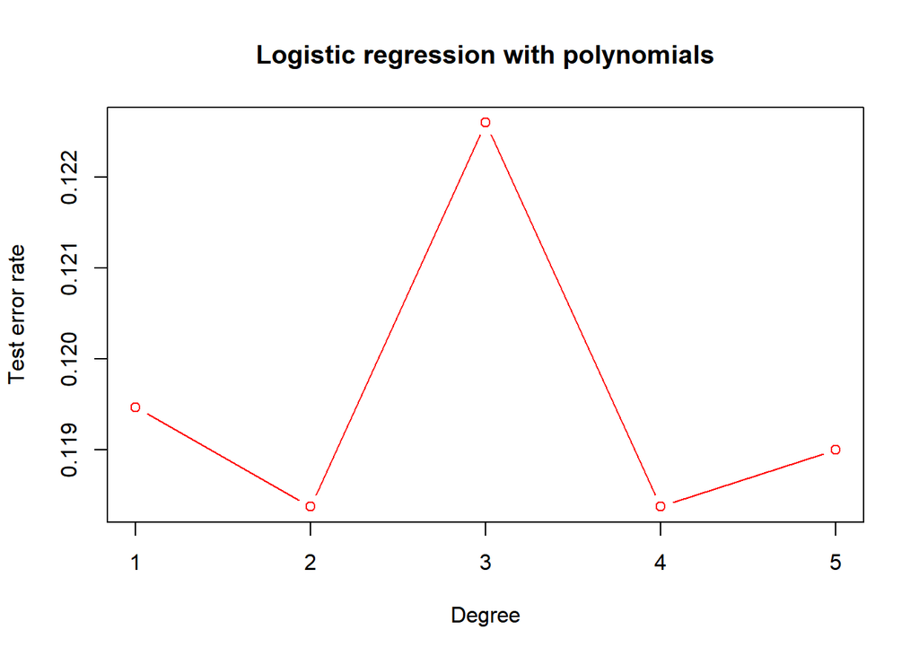

```r
plot(1:5, test.error, xlab = "Degree", ylab = "Test error rate", main = "Logistic regression with polynomials", type = "b", col="red")
```

```r
test.error
```

```
## [1] 0.1194683 0.1183737 0.1225958 0.1183737 0.1189992
```

The plot shows the best polynomial degree is 2, at which the test error rate is only 11.84%, which is better than the logistic model without polynomials and random guessing. In conclusion, the logistic regression using “OG”,“FG” ,“IBU” with their polynomials as predictors has the lowest test error rate, which is 11.84%.

#### Linear Discriminant Analysis

Now we use LDA on our training dataset.

```r
lda.fit = lda(Dark~ OG +FG +IBU, data = recipes.X.train)
lda.fit
```

```
## Call:
## lda(Dark ~ OG + FG + IBU, data = recipes.X.train)
##
## Prior probabilities of groups:
##        no       yes
## 0.8783056 0.1216944
##
## Group means:
##           OG       FG      IBU
## no  1.057632 1.013032 37.22889
## yes 1.064683 1.016177 40.36556
##
## Coefficients of linear discriminants:
##               LD1
## OG   1.580295e-01
## FG   2.214637e+02
## IBU -3.965612e-05
```

The Prior probabilities of groups show that 12.17% of the training observations are beers with a dark color.

```r
lda.pred = predict(lda.fit, recipes.X.test)
lda.class = lda.pred$class
table(lda.class, recipes.X.test$Dark)
```

```
##
## lda.class   no  yes
##       no  5592  731
##       yes   44   28
```

```r
mean(lda.class != recipes.X.test$Dark)
```

```
## [1] 0.1211884
```

The test error rate of LDA is 12.12%, which is smaller than random guessing.

#### KNN

Finally we can apply KNN function on our training dataset, as we regard this problem as a 2-class classification problem. K is up to 100.

```r
# standardized dataset
recipes.X.std.train= data.frame(scale(recipes.X.train[,-5]),Dark =recipes.X.train$Dark)
recipes.X.std.test= data.frame(scale(recipes.X.test[,-5]),Dark =recipes.X.test$Dark)

library(class)
accuracy <- rep(0,100)
for (i in 1:100) {
    predicted.color = knn(recipes.X.std.train[,-5],   recipes.X.std.test[,-5], recipes.X.std.train$Dark, k = i)
    accuracy[i]=sum(recipes.X.std.test$Dark==predicted.color)/length(predicted.color)
}

qplot(1:100,accuracy,geom="line", xlab="K", ylab="Accuracy", main = "Accuracy of KNN 2")+geom_vline(aes(xintercept =43), linetype ="dashed" ,color="red")
summary(accuracy)["Max."]
```

[output not shown]

#### Decision tree

We ca also apply decision tree on our dataset.

```r
m.tree = tree(Dark~., recipes.X.train)
summary(m.tree)
```

```
##
## Classification tree:
## tree(formula = Dark ~ ., data = recipes.X.train)
## Variables actually used in tree construction:
## [1] "FG"
## Number of terminal nodes:  2
## Residual mean deviance:  0.7065 = 40660 / 57550
## Misclassification error rate: 0.1217 = 7004 / 57554
```

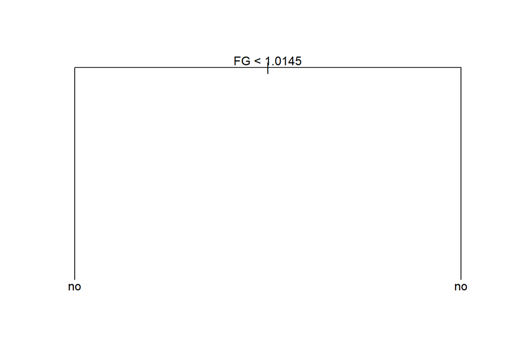

```r
plot(m.tree)
text(m.tree, pretty = 0)
```

We can see that decision tree is not suitable in my dataset. The main reason is that there are only two lables of “Dark” in my dataset, and most of observations belong to the “no” class. The plot can be interpreted that whatever final gravity is smaller or greater than 1.0145, the data item is classified into “no” label, which looks odd. In other words, all data items are predicted as not dark beers, which is just a random guessing. The training error rate is 12.17% and the test error rate is 11.87%.

#### Comparison and conclusion

Now we compare test error rates of different methods.

```r
Method.name = c("Random guessing","Logistic regression", "Logistic regression with polynomials", "KNN", "Linear Discriminant Analysis", "Decision tree")
Predictors = c("the whole dataset", "OG,FG,IBU","OG,FG,IBU and their polynomials","NA", "OG,FG,IBU","FG")
Test.error.rate = c("12.14%","12.20%", "11.85%", "11.45%", "12.12%","11.87%" )
comparison = data.frame(Method.name,Predictors,Test.error.rate)
require(knitr)
kable(comparison)
```

| Method.name | Predictors | Test.error.rate |
| --- | --- | --- |
| Random guessing | the whole dataset | 12.14% |
| Logistic regression | OG,FG,IBU | 12.20% |
| Logistic regression with polynomials | OG,FG,IBU and their polynomials | 11.85% |
| KNN | NA | 11.45% |
| Linear Discriminant Analysis | OG,FG,IBU | 12.12% |
| Decision tree | FG | 11.87% |

In conclusion, for the problem of predicting whether a given color is dark or not, the KNN function with the K = 43 works best, and the test error rate is around 11.45%, which seems acceptable.

## Notes

Gravity, in the context of fermenting alcoholic beverages, refers to the specific gravity, or relative density compared to water, of the wort or must at various stages in the fermentation. The concept is used in the brewing and wine-making industries. Specific gravity is measured by a hydrometer, refractometer, pycnometer or oscillating U-tube electronic meter.

Specific gravity is the ratio of the density of a sample to the density of water.

The difference between the original gravity of the wort and the final gravity of the beer is an indication of how much sugar has been turned into alcohol.

The Original Gravity is the specific gravity measured before fermentation.  
The Final Gravity is the specific gravity measured at the completion of fermentation.